# String Distance Metrics

2024-10-22

## Motivation and Goals

- Inspired by Cohen, Ravikumar, and Fienberg
- Explore various string distance metrics
- Conduct an experiment comparing the performance of metrics on name matching

## String Distance Metrics

- Will refer to both distance and similarity functions
- Small distance = Large similarity
- 3 Categories
  - Edit-distance
  - Token-based
  - Hybrid

## Edit-distance

- Calculated as the “cost” of the best order of edits to one string to convert it to another string
- Edits include character
  - Insertion
  - Deletion
  - Substitution
- Levenstein distance assigns a unit cost to all edits
- Jaro metric not an edit-distance metric, but broadly similar
  - Calculated based on the count and sequence of the common characters for a pair of strings
  - Jaro-Winkler extension incorporates size of the longest common prefix

## Token-based

- Treats each string as a multiset of characters or words called “tokens”
- Jaccard similarity calculated as the size of the intersection divided by the size of the union
- Cosine similarity another popular example

## Hybrid

- Calculated by combining multiple existing string distance metrics
- Popular examples
  - Monge and Elkan’s level 2 metric
  - “Soft” cosine similarity
- Cohen, Ravikumar, and Fienberg developed their own hybrid metric by training a binary SVM classifier with input features being scores from various existing metrics

## Experiment

- Explore 4 metrics
  - Edit-distance
    - Levenstein distance
    - Jaro-Winkler metric
  - Token-based
    - Jaccard similarity
    - Cosine similarity
- Compare each name with every name
- PR curve and AUC for each metric

## PR Curves

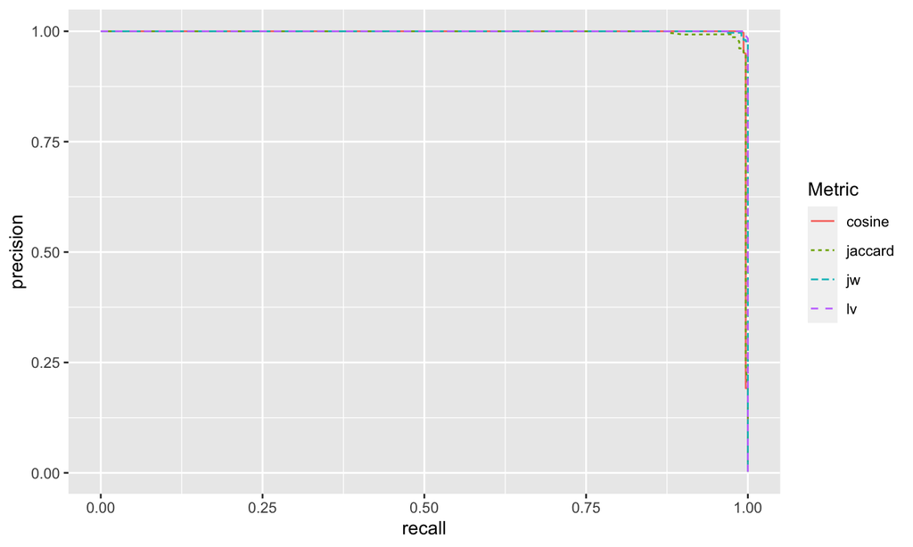

## PR AUCs

| Metric | PR AUC |
| --- | --- |
| lv | 0.99993 |
| jw | 0.99973 |
| jaccard | 0.99612 |
| cosine | 0.99713 |

## Future Directions

- More names in the example data set
- Generate more duplicate names with random errors to supplement the example data
- Explore different metrics such as the Monge-Elkan distance